# Assignment1

2025-06-18

```r
College = read.csv("~/Downloads/algoritmika/python pro 1 year/Дасаева София PP/Learning_R/Stanford/College.csv")
```

```r
rownames(College) = College[,1]
College= College[,-1]
```

by doing so we were able to make the name of university as the column and delete the name of university from actual data c)

```r
summary(College)
```

```
##    Private               Apps           Accept          Enroll
##  Length:777         Min.   :   81   Min.   :   72   Min.   :  35
##  Class :character   1st Qu.:  776   1st Qu.:  604   1st Qu.: 242
##  Mode  :character   Median : 1558   Median : 1110   Median : 434
##                     Mean   : 3002   Mean   : 2019   Mean   : 780
##                     3rd Qu.: 3624   3rd Qu.: 2424   3rd Qu.: 902
##                     Max.   :48094   Max.   :26330   Max.   :6392
##    Top10perc       Top25perc      F.Undergrad     P.Undergrad
##  Min.   : 1.00   Min.   :  9.0   Min.   :  139   Min.   :    1.0
##  1st Qu.:15.00   1st Qu.: 41.0   1st Qu.:  992   1st Qu.:   95.0
##  Median :23.00   Median : 54.0   Median : 1707   Median :  353.0
##  Mean   :27.56   Mean   : 55.8   Mean   : 3700   Mean   :  855.3
##  3rd Qu.:35.00   3rd Qu.: 69.0   3rd Qu.: 4005   3rd Qu.:  967.0
##  Max.   :96.00   Max.   :100.0   Max.   :31643   Max.   :21836.0
##     Outstate       Room.Board       Books           Personal
##  Min.   : 2340   Min.   :1780   Min.   :  96.0   Min.   : 250
##  1st Qu.: 7320   1st Qu.:3597   1st Qu.: 470.0   1st Qu.: 850
##  Median : 9990   Median :4200   Median : 500.0   Median :1200
##  Mean   :10441   Mean   :4358   Mean   : 549.4   Mean   :1341
##  3rd Qu.:12925   3rd Qu.:5050   3rd Qu.: 600.0   3rd Qu.:1700
##  Max.   :21700   Max.   :8124   Max.   :2340.0   Max.   :6800
##       PhD            Terminal       S.F.Ratio      perc.alumni
##  Min.   :  8.00   Min.   : 24.0   Min.   : 2.50   Min.   : 0.00
##  1st Qu.: 62.00   1st Qu.: 71.0   1st Qu.:11.50   1st Qu.:13.00
##  Median : 75.00   Median : 82.0   Median :13.60   Median :21.00
##  Mean   : 72.66   Mean   : 79.7   Mean   :14.09   Mean   :22.74
##  3rd Qu.: 85.00   3rd Qu.: 92.0   3rd Qu.:16.50   3rd Qu.:31.00
##  Max.   :103.00   Max.   :100.0   Max.   :39.80   Max.   :64.00
##      Expend        Grad.Rate
##  Min.   : 3186   Min.   : 10.00
##  1st Qu.: 6751   1st Qu.: 53.00
##  Median : 8377   Median : 65.00
##  Mean   : 9660   Mean   : 65.46
##  3rd Qu.:10830   3rd Qu.: 78.00
##  Max.   :56233   Max.   :118.00
```

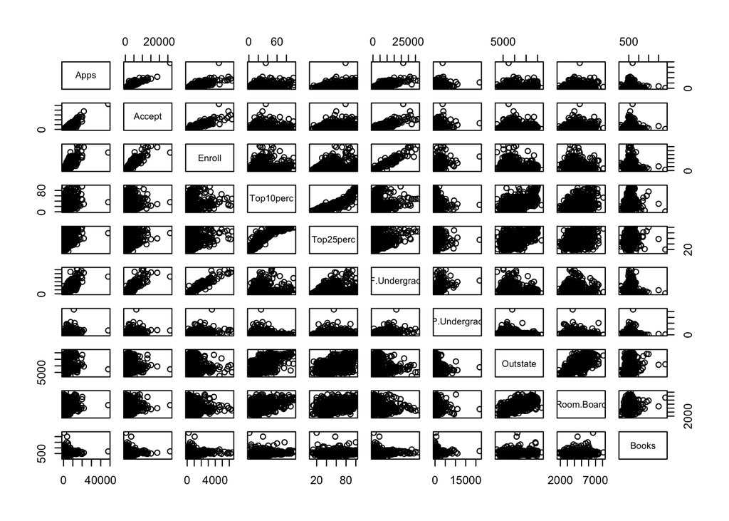

```r
pairs(College[,2:11])
```

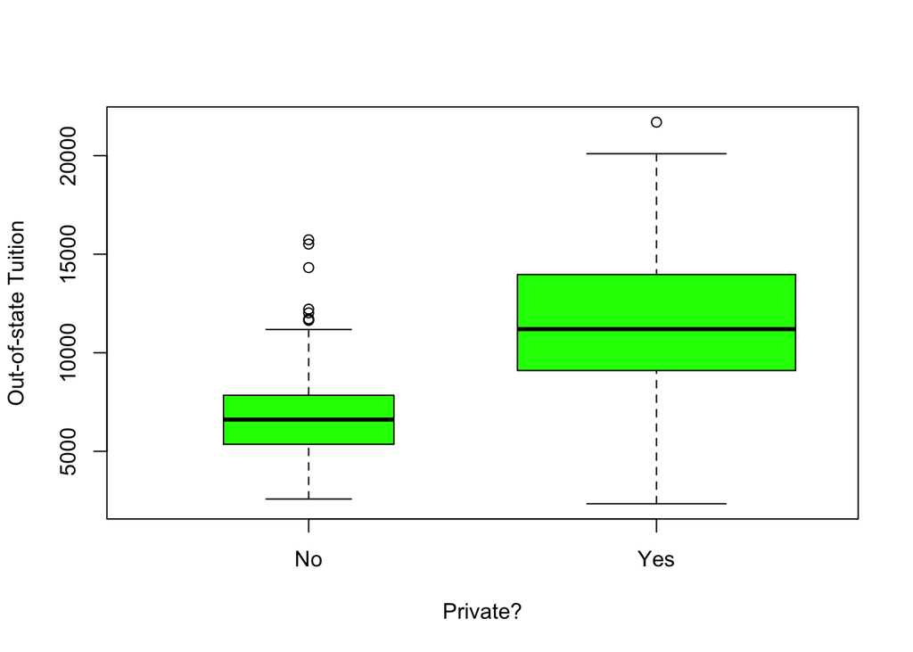

```r
attach(College)
Private = as.factor(Private)
plot(Private, Outstate,
     col      = "green",
     varwidth = TRUE,
     xlab     = "Private?",
     ylab     = "Out-of-state Tuition")
```

```r
attach(College)
Elite = rep("No", nrow(College))
Elite[Top10perc>50]="Yes"
Elite=as.factor(Elite)
College = data.frame(College, Elite)
summary(Elite)
```

```
##  No Yes
## 699  78
```

data.frame creates data frames, tightly coupled collections of variables which share many of the properties of matrices and of lists, used as the fundamental data structure by most of R’s modeling software.

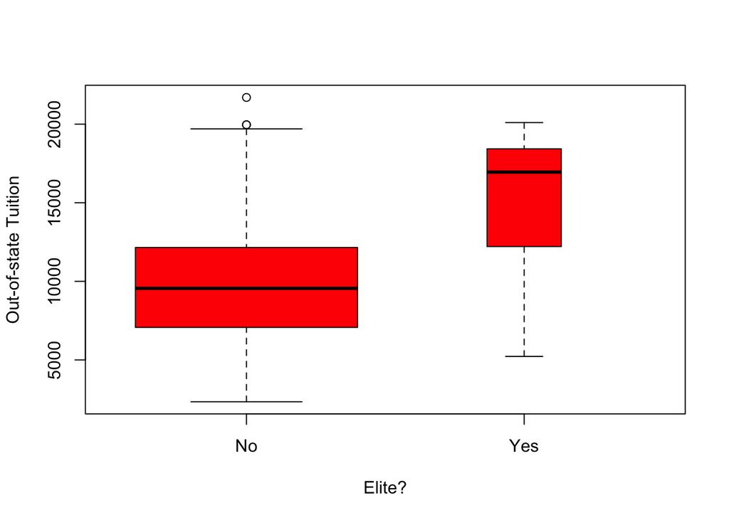

```r
plot(Elite, Outstate,
     col      = "red",
     varwidth = TRUE,
     xlab     = "Elite?",
     ylab     = "Out-of-state Tuition")
```

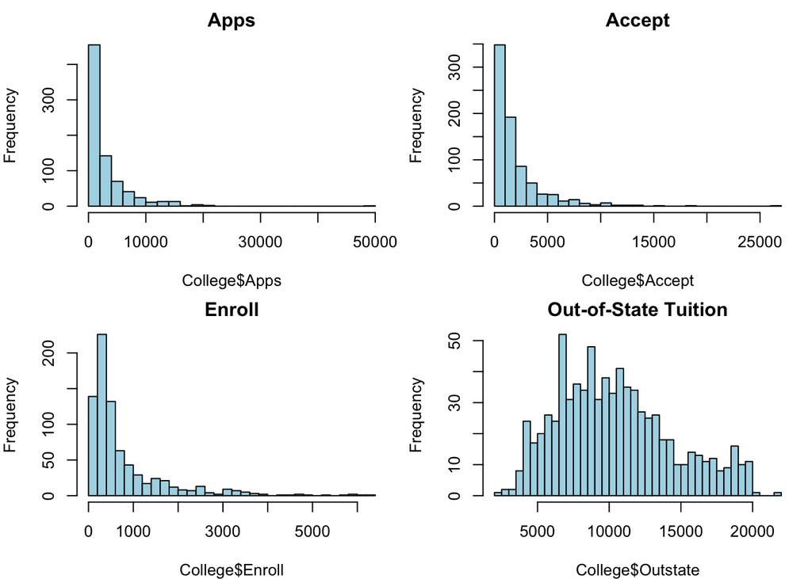

```r
par(mfrow = c(2,2), mar = c(4,4,2,1))
hist(College$Apps,      breaks = 30, col = "lightblue", main = "Apps")
hist(College$Accept,    breaks = 30, col = "lightblue", main = "Accept")
hist(College$Enroll,    breaks = 30, col = "lightblue", main = "Enroll")
hist(College$Outstate,  breaks = 30, col = "lightblue", main = "Out-of-State Tuition")
```

```r
par(mfrow = c(1,1))
```

The histograms for Apps, Accept, and Enroll are all heavily right-skewed: most colleges receive fewer than 5 000 applications, admit under 3 000 students, and enroll under 2 000, while a handful of large universities form a long tail of very high values. In comparison, Out-of-State Tuition is much more symmetrically distributed—most tuitions cluster between $8 000 and $15 000, with relatively few extreme outliers.

EXERCISE 9

```r
Auto = read.table("~/Downloads/algoritmika/python pro 1 year/Дасаева София PP/Learning_R/Stanford/Auto.data", header=T, na.strings="?") #means that this data sets has headers and that ? indicate missing values
#if its csv file, we might use read.csv()

Auto = na.omit(Auto)
```

```r
# numeric columns
quantitative <- names(Auto)[ sapply(Auto, is.numeric) ]

# factor/character columns
qualitative  <- names(Auto)[ sapply(Auto, function(x) is.factor(x) || is.character(x)) ]

quantitative
```

```
## [1] "mpg"          "cylinders"    "displacement" "horsepower"   "weight"
## [6] "acceleration" "year"         "origin"
```

```r
qualitative
```

```
## [1] "name"
```

```r
ranges <- sapply(Auto[, quantitative], range, na.rm = TRUE)
ranges
```

```
##       mpg cylinders displacement horsepower weight acceleration year origin
## [1,]  9.0         3           68         46   1613          8.0   70      1
## [2,] 46.6         8          455        230   5140         24.8   82      3
```

```r
means <- sapply(Auto[ , quantitative], mean, na.rm = TRUE)
means
```

```
##          mpg    cylinders displacement   horsepower       weight acceleration
##    23.445918     5.471939   194.411990   104.469388  2977.584184    15.541327
##         year       origin
##    75.979592     1.576531
```

```r
sds   <- sapply(Auto[ , quantitative], sd,   na.rm = TRUE)
sds
```

```
##          mpg    cylinders displacement   horsepower       weight acceleration
##    7.8050075    1.7057832  104.6440039   38.4911599  849.4025600    2.7588641
##         year       origin
##    3.6837365    0.8055182
```

```r
NewAuto = Auto[-(10:85), ]
Newranges <- sapply(NewAuto[ , quantitative], range, na.rm = TRUE)
Newmeans  <- sapply(NewAuto[ , quantitative], mean,  na.rm = TRUE)
Newsds    <- sapply(NewAuto[ , quantitative], sd,    na.rm = TRUE)

Newranges
```

```
##       mpg cylinders displacement horsepower weight acceleration year origin
## [1,] 11.0         3           68         46   1649          8.5   70      1
## [2,] 46.6         8          455        230   4997         24.8   82      3
```

```r
Newmeans
```

```
##          mpg    cylinders displacement   horsepower       weight acceleration
##    24.404430     5.373418   187.240506   100.721519  2935.971519    15.726899
##         year       origin
##    77.145570     1.601266
```

```r
Newsds
```

```
##          mpg    cylinders displacement   horsepower       weight acceleration
##     7.867283     1.654179    99.678367    35.708853   811.300208     2.693721
##         year       origin
##     3.106217     0.819910
```

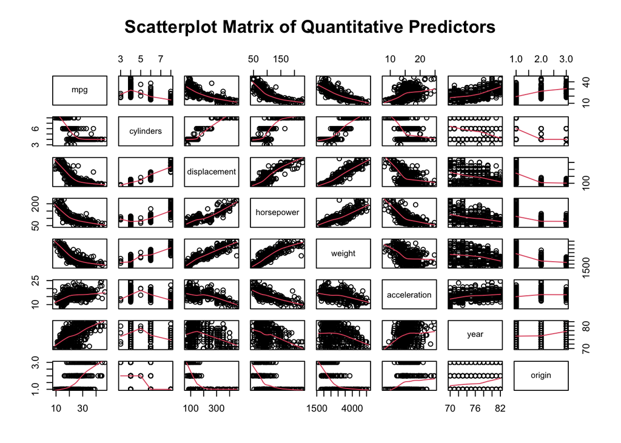

```r
pairs(Auto[ , quantitative],
      panel = panel.smooth,
      main  = "Scatterplot Matrix of Quantitative Predictors")
```

from these we can make more research

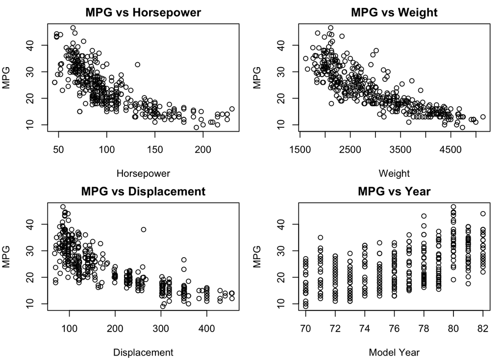

```r
par(mfrow = c(2,2), mar = c(4,4,2,1))
plot(Auto$horsepower, Auto$mpg,
     xlab = "Horsepower", ylab = "MPG",
     main = "MPG vs Horsepower")
plot(Auto$weight,     Auto$mpg,
     xlab = "Weight",     ylab = "MPG",
     main = "MPG vs Weight")
plot(Auto$displacement, Auto$mpg,
     xlab = "Displacement", ylab = "MPG",
     main = "MPG vs Displacement")
plot(Auto$year, Auto$mpg,
     xlab = "Model Year",  ylab = "MPG",
     main = "MPG vs Year")
```

```r
par(mfrow = c(1,1))
```

1. there’s a clear, almost linear downward trend—cars with more horsepower almost always get lower MPG.
2. heavier vehicles consistently show lower fuel economy, with the steepest drop in MPG between about 2 000 lb and 3 000 lb.
3. larger engine displacements correspond to lower MPG in a similar fashion to horsepower, confirming that engine size is a strong negative predictor of fuel efficiency.
4. there’s a modest upward trend—newer models (higher model year) tend to achieve slightly better MPG than older ones.

```r
correlations <- cor(Auto[ , c("mpg", quantitative)])
round(correlations["mpg", ], 2)
```

```
##          mpg        mpg.1    cylinders displacement   horsepower       weight
##         1.00         1.00        -0.78        -0.81        -0.78        -0.83
## acceleration         year       origin
##         0.42         0.58         0.57
```

EXERCISE 10

```r
library(MASS)
Boston
```

[output not shown]

[output cut: 999 more lines]

```r
dim(Boston)
```

```
## [1] 506  14
```

there are 506 rows and 14 columns

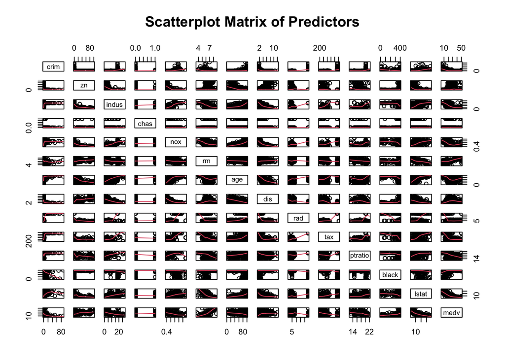

```r
pairs(Boston,
      panel = panel.smooth,
      main  = "Scatterplot Matrix of Predictors")
```

a lot of information

```r
cors <- cor(Boston)
crime_corrs <- sort(cors["crim", ], decreasing = TRUE)
round(crime_corrs, 2)
```

```
##    crim     rad     tax   lstat     nox   indus     age ptratio    chas      zn
##    1.00    0.63    0.58    0.46    0.42    0.41    0.35    0.29   -0.06   -0.20
##      rm     dis   black    medv
##   -0.22   -0.38   -0.39   -0.39
```

rad and tax mostly

```r
top_crime <- Boston[order(-Boston$crim), "crim"][1:5]
top_tax   <- Boston[order(-Boston$tax),   "tax"][1:5]
top_ptr   <- Boston[order(-Boston$ptratio),"ptratio"][1:5]

top_crime
```

```
## [1] 88.9762 73.5341 67.9208 51.1358 45.7461
```

```r
top_tax
```

```
## [1] 711 711 711 711 711
```

```r
top_ptr
```

```
## [1] 22.0 22.0 21.2 21.2 21.2
```

```r
ranges <- sapply(Boston, range, na.rm = TRUE)
ranges
```

```
##          crim  zn indus chas   nox    rm   age     dis rad tax ptratio  black
## [1,]  0.00632   0  0.46    0 0.385 3.561   2.9  1.1296   1 187    12.6   0.32
## [2,] 88.97620 100 27.74    1 0.871 8.780 100.0 12.1265  24 711    22.0 396.90
##      lstat medv
## [1,]  1.73    5
## [2,] 37.97   50
```

```r
n_chas <- sum(Boston$chas == 1)
n_chas
```

```
## [1] 35
```

```r
med_ptr <- median(Boston$ptratio)
med_ptr
```

```
## [1] 19.05
```

```r
idx_minmedv <- which.min(Boston$medv)
sub_minmedv <- Boston[idx_minmedv, ]
sub_minmedv
```

```
##        crim zn indus chas   nox    rm age    dis rad tax ptratio black lstat
## 399 38.3518  0  18.1    0 0.693 5.453 100 1.4896  24 666    20.2 396.9 30.59
##     medv
## 399    5
```

the suburb’s values are up there. Ranges are a little higher. It is an outlier on multiple fronts

```r
n_gt7 <- sum(Boston$rm > 7)
n_gt8 <- sum(Boston$rm > 8)
 n_gt7
```

```
## [1] 64
```

```r
 n_gt8
```

```
## [1] 13
```

64 suburbs average more than seven rooms per dwelling.

13 suburbs average more than eight rooms.